# 03 · El Pronóstico: ¿cuándo conviene ir?

**Torre del Caribe** · Fase 5 (A3 Pronóstico) · Autor: **Brandon Uriel García Sánchez** · UNRC, LCDN 5° semestre 2026-2

[output not shown]

```python
%matplotlib inline
import sys, warnings
from pathlib import Path
warnings.filterwarnings("ignore")
RAIZ = Path.cwd().parent if Path.cwd().name == "notebooks" else Path.cwd()
sys.path.insert(0, str(RAIZ / "backend"))

import numpy as np
import pandas as pd
from IPython.display import Image, display
from torre.pronostico import series, forma, modelos, intervalos, seleccion, escenarios
from torre.documento import figuras
pd.set_option("display.max_colwidth", 60)
pd.set_option("display.width", 200)
```

## 1. Qué se pronostica y qué meses no entrenan

El sur no tiene ocupación hotelera oficial desde 2025, así que se pronostican **series medidas que llegan a 2026**: visitantes INAH de la Bahía (Oxtankah) y de la Ruta (Kohunlich + Dzibanché + Ichkabal), cruces desde Belice por Chetumal y, como **referencia**, la ocupación de Cancún (el público de la campaña).

Un mes cerrado no es "cero demanda": los meses de **cierre**, **mes parcial** y **pandemia** se marcan y no entrenan (su valor se conserva).

```python
t = series.construir()
series.guardar(t)
series.resumen(t)
```

| serie | desde | hasta | meses | entrenan | cierre | mes parcial | pandemia |
| --- | --- | --- | --- | --- | --- | --- | --- |
| Bahía Calderitas–Oxtankah · visitantes INAH | 2016-01-01 | 2026-07-01 | 127 | 90 | 18.0 | 4.0 | 15.0 |
| Cancún (referencia) · ocupación hotelera | 2022-01-01 | 2026-07-01 | 55 | 55 | 0.0 | 0.0 | 0.0 |
| Chetumal · cruces desde Belice | 2019-01-01 | 2026-06-01 | 90 | 62 | 0.0 | 0.0 | 28.0 |
| Riviera Maya (referencia) · ocupación hotelera | 2022-01-01 | 2026-07-01 | 55 | 55 | 0.0 | 0.0 | 0.0 |
| Ruta arqueológica del sur · visitantes INAH | 2016-01-01 | 2026-07-01 | 127 | 91 | 18.0 | 4.0 | 14.0 |

```python
# Ejemplo de las reglas: la Ruta alrededor de las obras de 2024 y la reapertura de 2025
r = t[(t.serie.str.startswith("Ruta")) & t.periodo.between("2023-12-01", "2025-03-01")]
r[["periodo", "valor", "zonas_abiertas", "motivo_hueco", "entrena_flag"]]
```

|  | periodo | valor | zonas_abiertas | motivo_hueco | entrena_flag |
| --- | --- | --- | --- | --- | --- |
| 422 | 2023-12-01 | 5129.0 | 2.0 | None | True |
| 423 | 2024-01-01 | 4211.0 | 2.0 | mes parcial | False |
| 424 | 2024-02-01 | 2956.0 | 1.0 | cierre | False |
| 425 | 2024-03-01 | 0.0 | 0.0 | cierre | False |
| 426 | 2024-04-01 | 0.0 | 0.0 | cierre | False |
| 427 | 2024-05-01 | 0.0 | 0.0 | cierre | False |
| 428 | 2024-06-01 | 0.0 | 0.0 | cierre | False |
| 429 | 2024-07-01 | 0.0 | 0.0 | cierre | False |
| 430 | 2024-08-01 | 0.0 | 0.0 | cierre | False |
| 431 | 2024-09-01 | 0.0 | 0.0 | cierre | False |
| 432 | 2024-10-01 | 0.0 | 0.0 | cierre | False |
| 433 | 2024-11-01 | 0.0 | 0.0 | cierre | False |
| 434 | 2024-12-01 | 0.0 | 0.0 | cierre | False |
| 435 | 2025-01-01 | 6027.0 | 2.0 | cierre | False |
| 436 | 2025-02-01 | 9397.0 | 3.0 | mes parcial | False |
| 437 | 2025-03-01 | 6961.0 | 3.0 | None | True |

## 2. Minería: la forma del año

Índice del mes = promedio, entre los **años completos**, de (valor del mes ÷ promedio de ese año). Multiplicativo porque la temporada escala con el nivel. STL solo se usa como segunda opinión (necesita series sin huecos).

```python
fa, fu = forma.calcular(t)
forma.guardar(fa, fu)
fu[["serie", "anios_usados", "fuerza_estacional", "mes_mas_alto", "mes_mas_bajo", "corr_con_stl"]]
```

|  | serie | anios_usados | fuerza_estacional | mes_mas_alto | mes_mas_bajo | corr_con_stl |
| --- | --- | --- | --- | --- | --- | --- |
| 0 | Bahía Calderitas–Oxtankah · visitantes INAH | 2016, 2017, 2018, 2019, 2022, 2025 | 0.684 | 12 | 9 | 0.960 |
| 1 | Cancún (referencia) · ocupación hotelera | 2022, 2023, 2024, 2025 | 0.714 | 3 | 9 | 0.966 |
| 2 | Chetumal · cruces desde Belice | 2019, 2023, 2024, 2025 | 0.655 | 12 | 2 | 0.847 |
| 3 | Riviera Maya (referencia) · ocupación hotelera | 2022, 2023, 2024, 2025 | 0.728 | 2 | 9 | 0.972 |
| 4 | Ruta arqueológica del sur · visitantes INAH | 2016, 2017, 2018, 2019, 2022, 2023 | 0.793 | 1 | 9 | 0.955 |

```
razón ene-2019: 1.4846 | código: 1.4846
índice de enero (promedio de 6 años): 1.606
¿El sur acompaña al norte? {'Bahía Calderitas–Oxtankah': 0.716, 'Chetumal': 0.257, 'Ruta arqueológica del sur': 0.834}
```

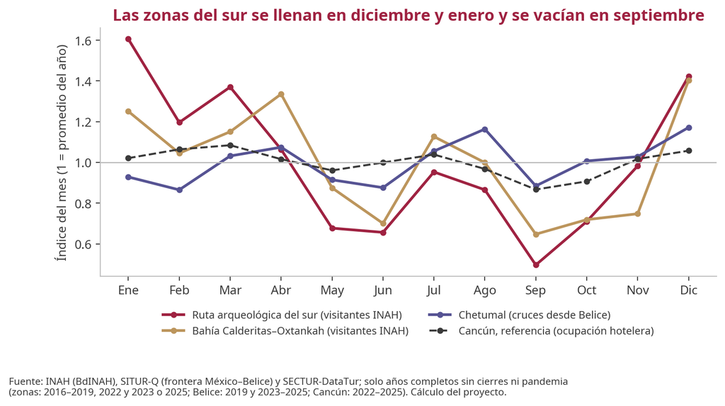

```python
# Ejemplo a mano: Ruta, enero de 2019 = 7,935 ÷ (64,139 / 12)
rz = forma.razones(t[t.serie.str.startswith("Ruta")])
print("razón ene-2019:", round(7935 / (64139 / 12), 4), "| código:", round(rz.loc[2019, 1], 4))
print("índice de enero (promedio de 6 años):", round(rz[1].mean(), 4))
print("¿El sur acompaña al norte?", forma.acompana_al_norte(fa).to_dict())
display(Image(filename=figuras.forma_del_anio()))
```

## 3. Aprendizaje de máquina: 5 modelos con origen móvil

Se "regresa el reloj" a cada mes desde 2019, se pronostican los 12 siguientes solo con lo que se sabía entonces y se compara con lo que pasó. Solo cuentan los pares que **los 5 modelos** pudieron pronosticar. "vs base" < 1 = mejor que repetir el mismo mes del año anterior.

```python
b, m = modelos.correr()   # ≈ 1.5 minutos
m[["serie", "modelo", "pronosticos", "mape", "mae_vs_base", "mape_h1–3", "mape_h4–6", "mape_h7–12"]].round(3)
```

|  | serie | modelo | pronosticos | mape | mae_vs_base | mape_h1–3 | mape_h4–6 | mape_h7–12 |
| --- | --- | --- | --- | --- | --- | --- | --- | --- |
| 0 | Bahía Calderitas–Oxtankah · visitantes INAH | Gradient Boosting con rezagos | 366 | 28.744 | 1.405 | 33.226 | 27.122 | 25.479 |
| 1 | Bahía Calderitas–Oxtankah · visitantes INAH | Holt-Winters con tendencia amortiguada | 366 | 27.584 | 1.524 | 22.212 | 27.712 | 32.977 |
| 2 | Bahía Calderitas–Oxtankah · visitantes INAH | Holt-Winters sin tendencia | 366 | 19.385 | 1.078 | 20.863 | 21.048 | 16.519 |
| 3 | Bahía Calderitas–Oxtankah · visitantes INAH | Línea base (ingenuo estacional) | 366 | 19.841 | 1.000 | 26.597 | 19.240 | 13.417 |
| 4 | Bahía Calderitas–Oxtankah · visitantes INAH | Regresión con clima | 366 | 15.650 | 0.898 | 17.457 | 15.386 | 14.016 |
| 5 | Cancún (referencia) · ocupación hotelera | Gradient Boosting con rezagos | 438 | 3.938 | 1.044 | 4.169 | 4.313 | 3.585 |
| 6 | Cancún (referencia) · ocupación hotelera | Holt-Winters con tendencia amortiguada | 438 | 6.842 | 1.838 | 5.960 | 8.393 | 6.503 |
| 7 | Cancún (referencia) · ocupación hotelera | Holt-Winters sin tendencia | 438 | 6.279 | 1.684 | 5.616 | 7.671 | 5.895 |
| 8 | Cancún (referencia) · ocupación hotelera | Línea base (ingenuo estacional) | 438 | 3.812 | 1.000 | 4.081 | 3.963 | 3.562 |
| 9 | Cancún (referencia) · ocupación hotelera | Regresión con clima | 438 | 6.025 | 1.584 | 5.524 | 6.293 | 6.180 |
| 10 | Chetumal · cruces desde Belice | Gradient Boosting con rezagos | 366 | 13.057 | 0.987 | 12.077 | 13.626 | 13.348 |
| 11 | Chetumal · cruces desde Belice | Holt-Winters con tendencia amortiguada | 366 | 17.115 | 1.238 | 10.278 | 15.210 | 22.573 |
| 12 | Chetumal · cruces desde Belice | Holt-Winters sin tendencia | 366 | 13.045 | 0.973 | 10.142 | 14.052 | 14.307 |
| 13 | Chetumal · cruces desde Belice | Línea base (ingenuo estacional) | 366 | 13.133 | 1.000 | 12.434 | 13.105 | 13.594 |
| 14 | Chetumal · cruces desde Belice | Regresión con clima | 366 | 10.986 | 0.820 | 10.426 | 10.804 | 11.448 |
| 15 | Riviera Maya (referencia) · ocupación hotelera | Gradient Boosting con rezagos | 438 | 6.745 | 1.081 | 6.214 | 6.953 | 6.953 |
| 16 | Riviera Maya (referencia) · ocupación hotelera | Holt-Winters con tendencia amortiguada | 438 | 11.510 | 1.934 | 8.404 | 14.328 | 11.812 |
| 17 | Riviera Maya (referencia) · ocupación hotelera | Holt-Winters sin tendencia | 438 | 10.365 | 1.724 | 7.946 | 13.338 | 10.160 |
| 18 | Riviera Maya (referencia) · ocupación hotelera | Línea base (ingenuo estacional) | 438 | 6.346 | 1.000 | 6.200 | 6.212 | 6.511 |
| 19 | Riviera Maya (referencia) · ocupación hotelera | Regresión con clima | 438 | 9.125 | 1.438 | 8.602 | 9.213 | 9.395 |
| 20 | Ruta arqueológica del sur · visitantes INAH | Gradient Boosting con rezagos | 378 | 34.422 | 1.074 | 32.252 | 33.000 | 37.730 |
| 21 | Ruta arqueológica del sur · visitantes INAH | Holt-Winters con tendencia amortiguada | 378 | 26.662 | 0.930 | 19.887 | 24.142 | 35.453 |
| 22 | Ruta arqueológica del sur · visitantes INAH | Holt-Winters sin tendencia | 378 | 20.059 | 0.639 | 18.237 | 19.468 | 22.354 |
| 23 | Ruta arqueológica del sur · visitantes INAH | Línea base (ingenuo estacional) | 378 | 27.870 | 1.000 | 28.572 | 27.137 | 27.754 |
| 24 | Ruta arqueológica del sur · visitantes INAH | Regresión con clima | 378 | 21.619 | 0.737 | 20.169 | 21.258 | 23.359 |

```python
# Hallazgo: la tendencia aprendida en plena reapertura produjo visitantes negativos
b[b.pronostico <= 0][["serie", "modelo", "origen", "destino", "pronostico", "real"]].round(1)
```

|  | serie | modelo | origen | destino | pronostico | real |
| --- | --- | --- | --- | --- | --- | --- |
| 1340 | Bahía Calderitas–Oxtankah · visitantes INAH | Holt-Winters con tendencia amortiguada | 2025-05-01 | 2026-02-01 | -39.0 | 896.0 |
| 1341 | Bahía Calderitas–Oxtankah · visitantes INAH | Holt-Winters con tendencia amortiguada | 2025-05-01 | 2026-03-01 | -122.3 | 1010.0 |
| 1342 | Bahía Calderitas–Oxtankah · visitantes INAH | Holt-Winters con tendencia amortiguada | 2025-05-01 | 2026-04-01 | -240.6 | 1080.0 |
| 1343 | Bahía Calderitas–Oxtankah · visitantes INAH | Holt-Winters con tendencia amortiguada | 2025-05-01 | 2026-05-01 | -221.2 | 713.0 |

## 4. El rango del 90 % y su cobertura real

Conformal secuencial: el tamaño del rango de un pronóstico sale solo de los errores ya conocidos en su origen, $\hat q = e_{(\lceil (n+1)\,0.9\rceil)}$, en escala logarítmica y por tramo de horizonte. Se reporta la cobertura aunque salga peor que 90 %.

```python
b, c = intervalos.correr()
c.round(1)
```

|  | serie | modelo | con_rango | cobertura_pct | ancho_mediano_pct |
| --- | --- | --- | --- | --- | --- |
| 0 | Bahía Calderitas–Oxtankah · visitantes INAH | Gradient Boosting con rezagos | 288 | 85.8 | 83.3 |
| 1 | Bahía Calderitas–Oxtankah · visitantes INAH | Holt-Winters con tendencia amortiguada | 288 | 87.8 | 108.0 |
| 2 | Bahía Calderitas–Oxtankah · visitantes INAH | Holt-Winters sin tendencia | 288 | 96.5 | 62.8 |
| 3 | Bahía Calderitas–Oxtankah · visitantes INAH | Línea base (ingenuo estacional) | 288 | 85.4 | 77.0 |
| 4 | Bahía Calderitas–Oxtankah · visitantes INAH | Regresión con clima | 288 | 91.3 | 43.1 |
| 5 | Cancún (referencia) · ocupación hotelera | Gradient Boosting con rezagos | 309 | 95.8 | 10.5 |
| 6 | Cancún (referencia) · ocupación hotelera | Holt-Winters con tendencia amortiguada | 309 | 100.0 | 18.8 |
| 7 | Cancún (referencia) · ocupación hotelera | Holt-Winters sin tendencia | 309 | 99.7 | 16.0 |
| 8 | Cancún (referencia) · ocupación hotelera | Línea base (ingenuo estacional) | 309 | 89.3 | 9.6 |
| 9 | Cancún (referencia) · ocupación hotelera | Regresión con clima | 309 | 93.2 | 15.4 |
| 10 | Chetumal · cruces desde Belice | Gradient Boosting con rezagos | 237 | 90.7 | 33.6 |
| 11 | Chetumal · cruces desde Belice | Holt-Winters con tendencia amortiguada | 237 | 92.8 | 52.1 |
| 12 | Chetumal · cruces desde Belice | Holt-Winters sin tendencia | 237 | 94.1 | 40.5 |
| 13 | Chetumal · cruces desde Belice | Línea base (ingenuo estacional) | 237 | 89.9 | 33.3 |
| 14 | Chetumal · cruces desde Belice | Regresión con clima | 237 | 94.1 | 25.9 |
| 15 | Riviera Maya (referencia) · ocupación hotelera | Gradient Boosting con rezagos | 309 | 74.4 | 11.4 |
| 16 | Riviera Maya (referencia) · ocupación hotelera | Holt-Winters con tendencia amortiguada | 309 | 98.1 | 32.4 |
| 17 | Riviera Maya (referencia) · ocupación hotelera | Holt-Winters sin tendencia | 309 | 97.1 | 27.7 |
| 18 | Riviera Maya (referencia) · ocupación hotelera | Línea base (ingenuo estacional) | 309 | 66.7 | 9.1 |
| 19 | Riviera Maya (referencia) · ocupación hotelera | Regresión con clima | 309 | 74.4 | 15.0 |
| 20 | Ruta arqueológica del sur · visitantes INAH | Gradient Boosting con rezagos | 300 | 81.3 | 87.2 |
| 21 | Ruta arqueológica del sur · visitantes INAH | Holt-Winters con tendencia amortiguada | 300 | 81.3 | 55.2 |
| 22 | Ruta arqueológica del sur · visitantes INAH | Holt-Winters sin tendencia | 300 | 72.3 | 44.7 |
| 23 | Ruta arqueológica del sur · visitantes INAH | Línea base (ingenuo estacional) | 300 | 74.3 | 63.0 |
| 24 | Ruta arqueológica del sur · visitantes INAH | Regresión con clima | 300 | 80.3 | 51.1 |

## 5. El modelo elegido (criterio de Brandon) y el pronóstico de 12 meses

Por serie, el menor error entre los modelos cuyo rango del 90 % se cumple al menos 80 de cada 100 veces.

```python
e, f = seleccion.correr()
e[e.elegido_flag][["serie", "modelo", "mae_vs_base", "mape", "cobertura_pct", "ancho_mediano_pct"]].round(3)
```

|  | serie | modelo | mae_vs_base | mape | cobertura_pct | ancho_mediano_pct |
| --- | --- | --- | --- | --- | --- | --- |
| 4 | Bahía Calderitas–Oxtankah · visitantes INAH | Regresión con clima | 0.898 | 15.650 | 91.3 | 43.1 |
| 8 | Cancún (referencia) · ocupación hotelera | Línea base (ingenuo estacional) | 1.000 | 3.812 | 89.3 | 9.6 |
| 14 | Chetumal · cruces desde Belice | Regresión con clima | 0.820 | 10.986 | 94.1 | 25.9 |
| 17 | Riviera Maya (referencia) · ocupación hotelera | Holt-Winters sin tendencia | 1.724 | 10.365 | 97.1 | 27.7 |
| 24 | Ruta arqueológica del sur · visitantes INAH | Regresión con clima | 0.737 | 21.619 | 80.3 | 51.1 |

```
n = 105, k = 96, q = 0.3132 → 1,311.1 × e^±q = 959 a 1,793
```

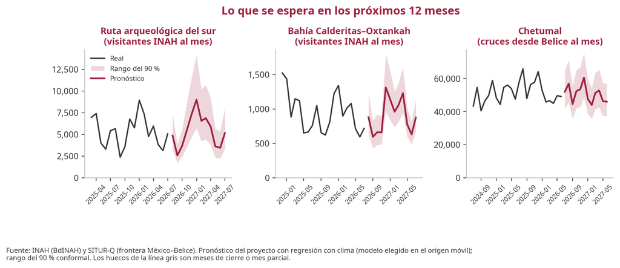

```python
# Ejemplo a mano del rango: Bahía, dic-2026 (horizonte 5, tramo 4–6)
import math
err = b[(b.serie.str.startswith("Bahía")) & (b.modelo == "Regresión con clima") & (b.tramo_h == "4–6")].error_log
n = len(err); k = math.ceil((n + 1) * 0.9); q = np.sort(err.to_numpy())[k - 1]
fila = f[(f.lugar == "Bahía Calderitas–Oxtankah") & (f.periodo == "2026-12-01")].iloc[0]
print(f"n = {n}, k = {k}, q = {q:.4f} → {fila.esperado_est:,.1f} × e^±q = {fila.esperado_est*np.exp(-q):,.0f} a {fila.esperado_est*np.exp(q):,.0f}")
display(Image(filename=figuras.pronostico_12_meses()))
```

## 6. Estocástico: tormentas, escenarios y sensibilidad

- **Poisson:** $P(N_m\ge1)=1-e^{-\hat\lambda_m}$ con los 31 eventos de 1966–2025.
- **Monte Carlo:** 10,000 futuros = pronóstico × un año completo de errores reales × tormentas sorteadas; el golpe de una tormenta es un **supuesto** (0 / 25 / 50 %) porque no se pudo medir.
- **Capacidad probada:** el mes más alto que cada lugar ya recibió.

```python
p, meses, anual, sens = escenarios.correr()
p.assign(prob_tormenta=lambda x: (x.prob_tormenta * 100).round(1))[["mes", "eventos", "lambda", "prob_tormenta"]]
```

|  | mes | eventos | lambda | prob_tormenta |
| --- | --- | --- | --- | --- |
| 0 | 1 | 0 | 0.000000 | 0.0 |
| 1 | 2 | 0 | 0.000000 | 0.0 |
| 2 | 3 | 0 | 0.000000 | 0.0 |
| 3 | 4 | 0 | 0.000000 | 0.0 |
| 4 | 5 | 1 | 0.016667 | 1.7 |
| 5 | 6 | 3 | 0.050000 | 4.9 |
| 6 | 7 | 1 | 0.016667 | 1.7 |
| 7 | 8 | 9 | 0.150000 | 13.9 |
| 8 | 9 | 8 | 0.133333 | 12.5 |
| 9 | 10 | 6 | 0.100000 | 9.5 |
| 10 | 11 | 3 | 0.050000 | 4.9 |
| 11 | 12 | 0 | 0.000000 | 0.0 |

```python
anual.round(0)
```

|  | serie | lugar | golpe_tormenta_supuesto | malo_p10_est | probable_p50_est | bueno_p90_est | esperado_modelo_est | riesgo_algun_mes_sobre_capacidad |
| --- | --- | --- | --- | --- | --- | --- | --- | --- |
| 0 | Bahía Calderitas–Oxtankah · visitantes INAH | Bahía Calderitas–Oxtankah | 0.0 | 10106.0 | 11217.0 | 13085.0 | 10771.0 | 0.0 |
| 1 | Bahía Calderitas–Oxtankah · visitantes INAH | Bahía Calderitas–Oxtankah | 0.0 | 10030.0 | 11140.0 | 12947.0 | 10771.0 | 0.0 |
| 2 | Bahía Calderitas–Oxtankah · visitantes INAH | Bahía Calderitas–Oxtankah | 0.0 | 9915.0 | 11019.0 | 12777.0 | 10771.0 | 0.0 |
| 3 | Cancún (referencia) · ocupación hotelera | Cancún | 0.0 | 820.0 | 835.0 | 849.0 | 854.0 | 0.0 |
| 4 | Chetumal · cruces desde Belice | Chetumal | 0.0 | 551986.0 | 620304.0 | 671956.0 | 606584.0 | 0.0 |
| 5 | Chetumal · cruces desde Belice | Chetumal | 0.0 | 546473.0 | 611505.0 | 661812.0 | 606584.0 | 0.0 |
| 6 | Chetumal · cruces desde Belice | Chetumal | 0.0 | 535346.0 | 606138.0 | 660162.0 | 606584.0 | 0.0 |
| 7 | Ruta arqueológica del sur · visitantes INAH | Ruta arqueológica del sur | 0.0 | 55811.0 | 62212.0 | 73884.0 | 64511.0 | 0.0 |
| 8 | Ruta arqueológica del sur · visitantes INAH | Ruta arqueológica del sur | 0.0 | 55401.0 | 61923.0 | 73410.0 | 64511.0 | 0.0 |
| 9 | Ruta arqueológica del sur · visitantes INAH | Ruta arqueológica del sur | 0.0 | 54751.0 | 61440.0 | 72628.0 | 64511.0 | 0.0 |
| 10 | Riviera Maya (referencia) · ocupación hotelera | Riviera Maya | 0.0 | 624.0 | 701.0 | 760.0 | 705.0 | 0.0 |

```
Meses con riesgo de rebasar la capacidad probada:
```

|  | lugar | periodo | probable_p50_est | capacidad_probada | riesgo_rebasar_capacidad |
| --- | --- | --- | --- | --- | --- |
| 4 | Bahía Calderitas–Oxtankah | 2026-12-01 | 1394.589 | 1639.0 | 0.140 |
| 49 | Chetumal | 2026-08-01 | 57487.638 | 65792.0 | 0.058 |
| 53 | Chetumal | 2026-12-01 | 63068.835 | 65792.0 | 0.290 |
| 89 | Ruta arqueológica del sur | 2027-01-01 | 9031.283 | 10465.0 | 0.304 |

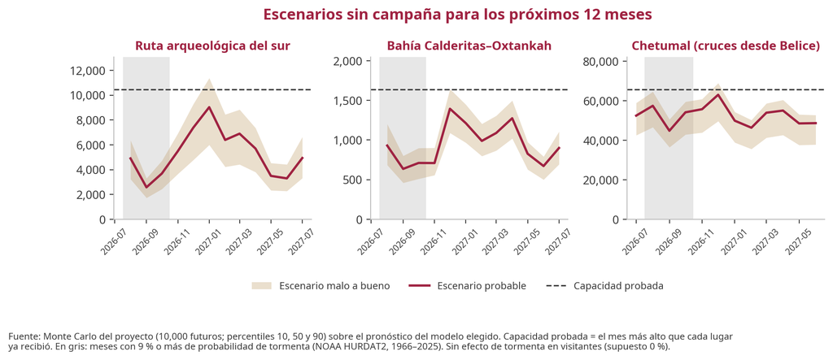

```python
x = meses[(meses.golpe_tormenta_supuesto == 0) & (meses.riesgo_rebasar_capacidad > 0.05)]
print("Meses con riesgo de rebasar la capacidad probada:")
display(x[["lugar", "periodo", "probable_p50_est", "capacidad_probada", "riesgo_rebasar_capacidad"]].round(3))
display(Image(filename=figuras.escenarios_12_meses()))
```

```python
sens[["lugar", "variable", "efecto_pct", "p_valor", "meses", "significativo_flag"]].round(3)
```

|  | lugar | variable | efecto_pct | p_valor | meses | significativo_flag |
| --- | --- | --- | --- | --- | --- | --- |
| 0 | Bahía Calderitas–Oxtankah | lluvia (+100 mm sobre lo normal) | -9.667 | 0.039 | 90 | True |
| 1 | Bahía Calderitas–Oxtankah | tipo de cambio (+1 peso por dólar) | -0.245 | 0.920 | 90 | False |
| 2 | Chetumal | lluvia (+100 mm sobre lo normal) | -4.696 | 0.031 | 62 | True |
| 3 | Chetumal | tipo de cambio (+1 peso por dólar) | 1.217 | 0.360 | 62 | False |
| 4 | Ruta arqueológica del sur | lluvia (+100 mm sobre lo normal) | -0.577 | 0.924 | 91 | False |
| 5 | Ruta arqueológica del sur | tipo de cambio (+1 peso por dólar) | 6.801 | 0.011 | 91 | True |

## 7. Qué se concluye

1. **La temporada manda:** las zonas del sur se llenan en diciembre–enero y se vacían en septiembre, y se mueven con el norte; los cruces desde Belice van por su cuenta.
2. **Un modelo simple y bien planteado le gana a los complejos:** la regresión con nivel por tramo + mes se equivoca entre 10 % y 26 % menos que la línea base en el sur; Holt-Winters con tendencia llegó a pronosticar visitantes negativos y Gradient Boosting, con tan pocos datos, perdió contra la base en la Bahía y la Ruta.
3. **El rango del 90 % se cumple** 91 % (Bahía) y 94 % (Belice) de las veces; en la Ruta, 80 % (falla en 2023). Se reporta como salió.
4. **Las tormentas pesan en el mes, no en el año;** el riesgo de rebasar la capacidad probada está en diciembre y enero.
5. **Limitaciones declaradas:** el efecto de las tormentas es un supuesto (solo 3 meses con tormenta en los datos usables); el clima futuro se toma como normal; la capacidad probada no es la capacidad física oficial; Maya Ka'an y la Laguna Milagros no tienen serie propia; los escenarios no incluyen la campaña (Fase 6).